# Como trabalhar com dados raciais no Brasil

Escola de Inverno IESP-UERJ · Material do aluno

Juliana Alves Marques e Amsatou Falilou Diop

18 de junho de 2026

# Apresentação

Este é o material de apoio do workshop **Como trabalhar com dados raciais no Brasil** (Escola de Inverno IESP-UERJ). Ele foi pensado para você acompanhar e replicar os exemplos durante a aula.

A pergunta que usaremos como fio condutor é:

> **Municípios com maior proporção de população negra elegem mais candidatos negros?**

Para respondê-la, vamos aprender três bases de dados – Censo 2022, PNAD Contínua e TSE – e depois usar a Base dos Dados para cruzá-las.

# 1 · Contexto metodológico

## 1.1 Autodeclaração

Nas pesquisas do IBGE, cada pessoa se classifica em uma das cinco categorias de cor ou raça: branca, preta, amarela, parda ou indígena. Isso é chamado de **autodeclaração** – contrasta com a **heteroidentificação**, em que terceiros classificam com base na aparência.

| Dimensão | Autodeclaração | Heteroidentificação |
| --- | --- | --- |
| Quem classifica | O próprio indivíduo | Terceiro(s) |
| Critério | Identidade subjetiva | Aparência fenotípica |
| Uso principal | Censos, PNADs | Cotas, políticas afirmativas |

## 1.2 A categoria “negros”

A operação mais comum na análise de desigualdade racial no Brasil é somar pretos e pardos para formar a categoria “negros”. Isso se justifica porque as duas categorias ocupam posição estrutural semelhante no mercado de trabalho, na renda e na escolaridade.

**Comunicando resultados**: sempre que somar pretos e pardos, deixe explícito na primeira vez: “negros (pretos e pardos, conforme categorias do IBGE)”.

# 2 · De onde vêm os dados raciais?

## 2.1 Panorama das principais fontes

| Fonte | Dado racial desde | Unidade de análise |
| --- | --- | --- |
| Censo Demográfico | 1940 (com intervalos) | Pessoa |
| PNAD Contínua | 2012 | Pessoa |
| TSE – candidatos | 2014 | Candidato |
| Censo Escolar (INEP) | 2005 | Escola (ver nota) |
| SUS – SINASC e SIM | 1996 | Evento vital |

**Censo Escolar:** o INEP está restringindo o acesso a dados individuais por conta da LGPD. O dado disponível publicamente é hoje agregado por escola, não por aluno.

## 2.2 A Base dos Dados

A [Base dos Dados](https://basedosdados.org/) é uma plataforma que disponibiliza dados públicos brasileiros tratados no Google BigQuery. Em vez de baixar arquivos brutos e fazer joins manualmente, você consulta via SQL e recebe os dados já limpos – com chaves compatíveis entre fontes distintas.

| Recurso | Link |
| --- | --- |
| Catálogo de bases | [basedosdados.org](https://basedosdados.org/) |
| TSE na Base dos Dados | br-tse-eleicoes |
| Censo na Base dos Dados | br-ibge-censo-demografico |

# Configuração inicial

```r
# Locale garante leitura correta de acentos e datas em português
Sys.setlocale(category = "LC_ALL", locale = "pt_BR.UTF-8")
```

```
#> [1] "LC_COLLATE=pt_BR.UTF-8;LC_CTYPE=pt_BR.UTF-8;LC_MONETARY=pt_BR.UTF-8;LC_NUMERIC=C;LC_TIME=pt_BR.UTF-8"
```

```r
# Configuracao global dos blocos de código:
# echo = TRUE mostra o código; warning/message = FALSE omite avisos técnicos
knitr::opts_chunk$set(
  echo    = TRUE,
  warning = FALSE,
  message = FALSE
)

# Diretório de trabalho -- ajuste para a pasta da aula
setwd("~/Downloads")
```

```
#> Error in setwd("~/Downloads"): não é possível mudar o diretório de trabalho
```

```r
dir.create("dados",    showWarnings = FALSE)
dir.create("graficos", showWarnings = FALSE)

library(tidyverse)
library(scales)
```

# 3 · Parte 1 – Censo 2022

Para o Censo 2022, temos dois pacotes em R:

- **[`censobr`](https://ipeagit.github.io/censobr/)** (IPEA): acessa microdados – cada linha é uma pessoa.
- **[`sidrar`](https://cran.r-project.org/web/packages/sidrar/vignettes/Introduction_to_sidrar.html)**: acessa tabelas agregadas do SIDRA via API.

```r
library(sidrar)
```

```r
# install.packages(c("censobr", "arrow"))
library(censobr)
library(arrow)   # necessario para trabalhar com censobr
```

## 3.1 Variáveis de interesse

### Via censobr (microdados)

| Variável | Descrição |
| --- | --- |
| `V0606` | Cor ou raça |
| `V0010` | Peso amostral |
| `name_region` | Nome da grande região (adicionado automaticamente) |

### Via sidrar (tabela agregada)

| Parâmetro | Valor | Descrição |
| --- | --- | --- |
| `x` | 9605 | Tabela: população por cor ou raça |
| `variable` | 93 | Variável: total de pessoas |
| `geo` | “Region” / “State” / “City” | Nível geográfico |

## 3.2 Baixando os dados

### Via censobr (microdados)

```r
pop_censo_arrow <- read_population(
  year         = 2022,
  columns      = c("name_region", "V0606", "V0010"),
  add_labels   = "pt",
  showProgress = FALSE
)

pop_censo <- pop_censo_arrow %>%
  collect() %>%
  filter(!is.na(V0606)) %>%
  rename(cor_raca = V0606, peso = V0010, regiao = name_region) %>%
  mutate(
    grupo = case_when(
      cor_raca %in% c("Preta", "Parda") ~ "Negros",
      cor_raca == "Branca"              ~ "Brancos",
      cor_raca == "Amarela"             ~ "Amarelos",
      cor_raca == "Indígena"            ~ "Indígenas",
      TRUE                              ~ NA_character_
    )
  ) %>%
  group_by(regiao, grupo) %>%
  summarise(populacao = sum(peso, na.rm = TRUE), .groups = "drop") %>%
  group_by(regiao) %>%
  mutate(proporcao = populacao / sum(populacao)) %>%
  ungroup() %>%
  filter(!is.na(grupo))

pop_censo
```

### Via sidrar (tabela agregada)

```r
pop_raca_raw <- get_sidra(
  x        = 9605,
  variable = 93,
  geo      = "Region"
)

glimpse(pop_raca_raw)
```

```
#> Rows: 30
#> Columns: 13
#> $ `Nível Territorial (Código)` <chr> "2", "2", "2", "2", "2", "2", "2", "2", "…
#> $ `Nível Territorial`          <chr> "Grande Região", "Grande Região", "Grande…
#> $ `Unidade de Medida (Código)` <chr> "45", "45", "45", "45", "45", "45", "45",…
#> $ `Unidade de Medida`          <chr> "Pessoas", "Pessoas", "Pessoas", "Pessoas…
#> $ Valor                        <dbl> 17354884, 3598298, 1530418, 29467, 116543…
#> $ `Grande Região (Código)`     <chr> "1", "1", "1", "1", "1", "1", "2", "2", "…
#> $ `Grande Região`              <chr> "Norte", "Norte", "Norte", "Norte", "Nort…
#> $ `Ano (Código)`               <chr> "2022", "2022", "2022", "2022", "2022", "…
#> $ Ano                          <chr> "2022", "2022", "2022", "2022", "2022", "…
#> $ `Variável (Código)`          <chr> "93", "93", "93", "93", "93", "93", "93",…
#> $ Variável                     <chr> "População residente", "População residen…
#> $ `Cor ou raça (Código)`       <chr> "95251", "2776", "2777", "2778", "2779", …
#> $ `Cor ou raça`                <chr> "Total", "Branca", "Preta", "Amarela", "P…
```

```r
pop_grupo <- pop_raca_raw %>%
  dplyr::select(
    regiao    = `Grande Região`,
    cor_raca  = `Cor ou raça`,
    populacao = Valor
  ) %>%
  filter(cor_raca != "Total", !is.na(populacao)) %>%
  mutate(
    grupo = case_when(
      cor_raca %in% c("Preta", "Parda") ~ "Negros",
      cor_raca == "Branca"              ~ "Brancos",
      cor_raca == "Amarela"             ~ "Amarelos",
      cor_raca == "Indígena"            ~ "Indígenas",
      TRUE                              ~ NA_character_
    )
  ) %>%
  group_by(regiao, grupo) %>%
  summarise(populacao = sum(populacao, na.rm = TRUE), .groups = "drop") %>%
  group_by(regiao) %>%
  mutate(proporcao = populacao / sum(populacao)) %>%
  ungroup() %>%
  filter(!is.na(grupo))

pop_grupo
```

```
#> # A tibble: 20 × 4
#>    regiao       grupo     populacao proporcao
#>    <chr>        <chr>         <dbl>     <dbl>
#>  1 Centro-Oeste Amarelos      60224   0.00370
#>  2 Centro-Oeste Brancos     6033785   0.370
#>  3 Centro-Oeste Indígenas    168684   0.0104
#>  4 Centro-Oeste Negros     10026403   0.616
#>  5 Nordeste     Amarelos      68749   0.00126
#>  6 Nordeste     Brancos    14571557   0.267
#>  7 Nordeste     Indígenas    327725   0.00600
#>  8 Nordeste     Negros     39686864   0.726
#>  9 Norte        Amarelos      29467   0.00170
#> 10 Norte        Brancos     3598298   0.207
#> 11 Norte        Indígenas    539821   0.0311
#> 12 Norte        Negros     13184808   0.760
#> 13 Sudeste      Amarelos     570852   0.00673
#> 14 Sudeste      Brancos    42318768   0.499
#> 15 Sudeste      Indígenas    109934   0.00130
#> 16 Sudeste      Negros     41836761   0.493
#> 17 Sul          Amarelos     120838   0.00404
#> 18 Sul          Brancos    21729713   0.726
#> 19 Sul          Indígenas     81478   0.00272
#> 20 Sul          Negros      8004908   0.267
```

**Exercício 1** Troque `geo = "Region"` por `geo = "Brazil"` para obter os totais nacionais. Qual é a proporção de negros no Brasil segundo o Censo 2022? Compare com a região Norte.

# 4 · Parte 2 – PNADC nos anos intercensitários

O Censo acontece a cada dez anos. A **PNAD Contínua** preenche os anos entre censos com dados trimestrais sobre renda, escolaridade e ocupação.

```r
library(PNADcIBGE)   # install.packages("PNADcIBGE")
```

## 4.1 Variáveis de interesse

| Variável | Descrição |
| --- | --- |
| `V1028` | Peso amostral – usar sempre em médias ponderadas |
| `V2010` | Cor ou raça |
| `VD3005` | Anos de estudo |
| `VD4017` | Rendimento mensal efetivo do trabalho principal (R$) |

## 4.2 Download

```r
pnadc_raw <- PNADcIBGE::get_pnadc(
  year    = 2022,
  quarter = 1,
  design  = FALSE
)
```

```r
pnadc <- pnadc_raw %>%
  select(V1028, V2010, VD3005, VD4017) %>%
  mutate(
    grupo = case_when(
      V2010 %in% c("Preta", "Parda") ~ "Negros",
      V2010 == "Branca"              ~ "Brancos",
      TRUE                           ~ V2010
    )
  ) %>%
  filter(!is.na(grupo))
```

```r
renda_raca <- pnadc %>%
  filter(!is.na(VD4017)) %>%
  group_by(grupo) %>%
  summarise(
    renda_media = weighted.mean(VD4017, w = V1028, na.rm = TRUE),
    anos_estudo = weighted.mean(VD3005, w = V1028, na.rm = TRUE),
    n = n(),
    .groups = "drop"
  ) %>%
  arrange(desc(renda_media))

renda_raca
```

## 4.3 Dados para visualização

Valores baseados em estimativas da PNADC 2022 – substitua por `renda_raca` após rodar a seção 4.2.

```r
df_renda_sim <- tibble::tribble(
  ~cor_raca,   ~renda_media, ~anos_estudo,
  "Branca",        2917,         9.8,
  "Amarela",       3282,        10.5,
  "Preta",         1563,         8.2,
  "Parda",         1533,         8.0,
  "Indígena",      1248,         7.1
) %>%
  mutate(
    grupo    = case_when(
      cor_raca %in% c("Preta", "Parda") ~ "Negros",
      TRUE                              ~ cor_raca
    ),
    cor_raca = forcats::fct_reorder(cor_raca, renda_media)
  )

df_renda_sim
```

```
#> # A tibble: 5 × 4
#>   cor_raca renda_media anos_estudo grupo
#>   <fct>          <dbl>       <dbl> <chr>
#> 1 Branca          2917         9.8 Branca
#> 2 Amarela         3282        10.5 Amarela
#> 3 Preta           1563         8.2 Negros
#> 4 Parda           1533         8   Negros
#> 5 Indígena        1248         7.1 Indígena
```

**Exercício 2** Usando `df_renda_sim`, crie um gráfico de dispersão com `renda_media` no eixo X e `anos_estudo` no Y. Identifique cada ponto pelo nome da categoria. O que o padrão sugere?

# 5 · Visualização

## 5.1 Paleta de cores

```r
cores_grupo <- c(
  "Negros"    = "#0f2a4a",
  "Brancos"   = "#5baad4",
  "Indígenas" = "#7fb3d3",
  "Amarelos"  = "#a8c8e8"
)

cores_censo <- c(
  "Branca"   = "#5baad4",
  "Amarela"  = "#a8c8e8",
  "Preta"    = "#0f2a4a",
  "Parda"    = "#1d3557",
  "Indígena" = "#7fb3d3"
)
```

## 5.2 Composição racial por região (Censo 2022)

O gráfico mostra a distribuição das categorias censitárias em cada grande região. A proporção de negros varia bastante entre regiões, o que já sugere que cruzar esse dado com representação política precisará levar o recorte geográfico em conta.

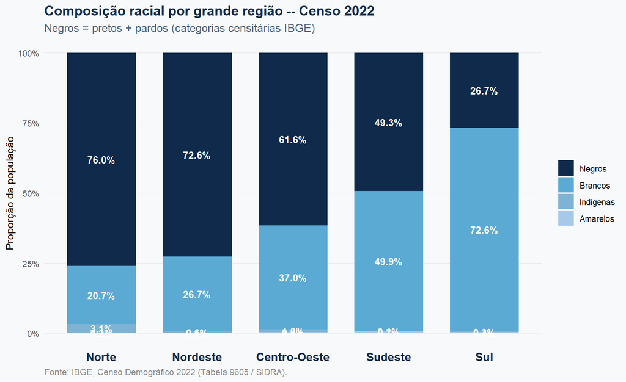

```r
ordem_regioes <- c("Norte", "Nordeste", "Centro-Oeste", "Sudeste", "Sul")

pop_grupo %>%
  filter(grupo %in% names(cores_grupo)) %>%
  mutate(
    regiao = factor(regiao, levels = ordem_regioes),
    grupo  = factor(grupo,  levels = names(cores_grupo))
  ) %>%
  ggplot(aes(x = regiao, y = proporcao, fill = grupo)) +
  geom_col(position = "fill", width = 0.72) +
  geom_text(
    aes(label = percent(proporcao, accuracy = 0.1)),
    position = position_fill(vjust = 0.5),
    color = "white", size = 3.5, fontface = "bold"
  ) +
  scale_y_continuous(labels = percent_format()) +
  scale_fill_manual(values = cores_grupo, name = NULL) +
  labs(
    title    = "Composição racial por grande região -- Censo 2022",
    subtitle = "Negros = pretos + pardos (categorias censitárias IBGE)",
    x = NULL, y = "Proporção da população",
    caption  = "Fonte: IBGE, Censo Demográfico 2022 (Tabela 9605 / SIDRA)."
  ) +
  theme_minimal(base_family = "sans") +
  theme(
    plot.title         = element_text(color = "#0f2a4a", face = "bold", size = 14),
    plot.subtitle      = element_text(color = "#4a6580", size = 11.5),
    plot.caption       = element_text(color = "#888888", size = 9, hjust = 0),
    axis.text.x        = element_text(color = "#0f2a4a", face = "bold", size = 12),
    legend.position    = "right",
    panel.grid.major.x = element_blank(),
    panel.grid.minor   = element_blank(),
    plot.background    = element_rect(fill = "#f8f9fb", color = NA),
    panel.background   = element_rect(fill = "#f8f9fb", color = NA)
  )
```

## 5.3 Rendimento médio por cor ou raça

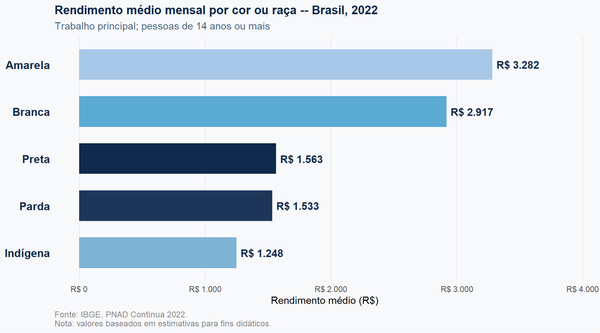

```r
ggplot(df_renda_sim, aes(x = cor_raca, y = renda_media, fill = cor_raca)) +
  geom_col(width = 0.65, show.legend = FALSE) +
  geom_text(
    aes(label = dollar(renda_media, prefix = "R$ ",
                       big.mark = ".", decimal.mark = ",")),
    hjust = -0.1, size = 4, color = "#0f2a4a", fontface = "bold"
  ) +
  coord_flip(clip = "off") +
  scale_y_continuous(
    limits = c(0, 3900),
    labels = dollar_format(prefix = "R$ ", big.mark = ".", decimal.mark = ",")
  ) +
  scale_fill_manual(values = cores_censo) +
  labs(
    title    = "Rendimento médio mensal por cor ou raça -- Brasil, 2022",
    subtitle = "Trabalho principal; pessoas de 14 anos ou mais",
    x = NULL, y = "Rendimento médio (R$)",
    caption  = "Fonte: IBGE, PNAD Contínua 2022.\nNota: valores baseados em estimativas para fins didáticos."
  ) +
  theme_minimal(base_family = "sans") +
  theme(
    plot.title         = element_text(color = "#0f2a4a", face = "bold", size = 13),
    plot.subtitle      = element_text(color = "#4a6580", size = 11),
    plot.caption       = element_text(color = "#888888", size = 9, hjust = 0),
    axis.text.y        = element_text(color = "#0f2a4a", face = "bold", size = 12),
    panel.grid.major.y = element_blank(),
    panel.grid.minor   = element_blank(),
    plot.background    = element_rect(fill = "#f8f9fb", color = NA),
    panel.background   = element_rect(fill = "#f8f9fb", color = NA)
  )
```

## 5.4 Razão de desigualdade

```r
razao_tab <- df_renda_sim %>%
  group_by(grupo) %>%
  summarise(renda_grupo = mean(renda_media), .groups = "drop") %>%
  filter(grupo %in% c("Brancos", "Negros"))

razao_tab
```

```
#> # A tibble: 1 × 2
#>   grupo  renda_grupo
#>   <chr>        <dbl>
#> 1 Negros        1548
```

```r
razao_val <- razao_tab$renda_grupo[razao_tab$grupo == "Brancos"] /
             razao_tab$renda_grupo[razao_tab$grupo == "Negros"]

print(paste("Razão de rendimentos (brancos / negros):", round(razao_val, 2)))
```

[output not shown]

# 6 · Parte 3 – Base dos Dados: Censo + TSE

```r
library(basedosdados)
library(DBI)
library(bigrquery)
```

## 6.1 Campos das tabelas TSE (Base dos Dados)

### Tabela `candidatos`

| Campo | Descrição |
| --- | --- |
| `ano` | Ano da eleição |
| `cargo` | Cargo disputado |
| `raca` | Cor ou raça autodeclarada |
| `resultado` | Eleito / Não eleito / Suplente |
| `id_municipio` | Código IBGE do município |
| `sigla_uf` | Estado |
| `ds_genero` | Gênero |

### Tabela `resultados_candidato`

| Campo | Descrição |
| --- | --- |
| `ano` | Ano da eleição |
| `id_candidato_bd` | Chave para join com `candidatos` |
| `votos` | Total de votos |
| `proporcao_votos` | Proporção dos votos válidos |
| `turno` | Turno da eleição |

## 6.2 Configuração do BigQuery

```r
bigrquery::bq_auth()
basedosdados::set_billing_id("seu-projeto-no-gcp")

con <- DBI::dbConnect(
  bigrquery::bigquery(),
  billing = "seu-projeto-no-gcp",
  project = "basedosdados"
)
```

## 6.3 Dados por município

```r
pop_municipios <- get_sidra(x = 9605, variable = 93, geo = "City")

prop_negros_mun <- pop_municipios %>%
  select(
    id_municipio_sidra = `Município (Código)`,
    municipio          = Município,
    cor_raca           = `Cor ou raça`,
    populacao          = Valor
  ) %>%
  filter(cor_raca != "Total", !is.na(populacao)) %>%
  mutate(grupo = case_when(
    cor_raca %in% c("Preta", "Parda") ~ "Negros",
    TRUE                              ~ cor_raca
  )) %>%
  group_by(id_municipio_sidra, municipio, grupo) %>%
  summarise(populacao = sum(populacao), .groups = "drop") %>%
  group_by(id_municipio_sidra) %>%
  mutate(prop = populacao / sum(populacao)) %>%
  ungroup() %>%
  filter(grupo == "Negros") %>%
  select(id_municipio_sidra, municipio, prop_negros = prop) %>%
  mutate(id_municipio = stringr::str_sub(as.character(id_municipio_sidra), 1, 6))
```

## 6.4 Candidatos negros eleitos – TSE 2022

```r
query_candidatos <- "
  SELECT
    id_municipio,
    raca AS cor_raca_tse,
    COUNT(*) AS n_candidatos,
    COUNTIF(resultado = 'Eleito') AS n_eleitos
  FROM `basedosdados.br_tse_eleicoes.candidatos`
  WHERE ano = 2022 AND cargo = 'Vereador' AND raca IS NOT NULL
  GROUP BY id_municipio, raca
"

df_tse <- DBI::dbGetQuery(con, query_candidatos)

prop_negros_tse <- df_tse %>%
  mutate(grupo_tse = case_when(
    cor_raca_tse %in% c("PRETA", "PARDA") ~ "Negros",
    TRUE                                   ~ cor_raca_tse
  )) %>%
  group_by(id_municipio, grupo_tse) %>%
  summarise(candidatos = sum(n_candidatos), eleitos = sum(n_eleitos), .groups = "drop") %>%
  group_by(id_municipio) %>%
  mutate(
    prop_cand_negros    = candidatos / sum(candidatos),
    prop_eleitos_negros = eleitos    / sum(eleitos)
  ) %>%
  ungroup() %>%
  filter(grupo_tse == "Negros") %>%
  select(id_municipio, prop_cand_negros, prop_eleitos_negros)
```

## 6.5 Visualizando a relação

```r
set.seed(42)
n <- 500
df_cruzado_sim <- tibble::tibble(
  prop_negros = runif(n, 0.05, 0.92),
  ruido       = rnorm(n, 0, 0.09)
) %>%
  mutate(
    prop_eleitos_negros = pmin(0.95, pmax(0.01,
      0.38 * prop_negros + 0.04 + ruido))
  ) %>%
  select(-ruido)

head(df_cruzado_sim)
```

```
#> # A tibble: 6 × 2
#>   prop_negros prop_eleitos_negros
#>         <dbl>               <dbl>
#> 1       0.846              0.263
#> 2       0.865              0.373
#> 3       0.299              0.0457
#> 4       0.772              0.351
#> 5       0.608              0.388
#> 6       0.502              0.138
```

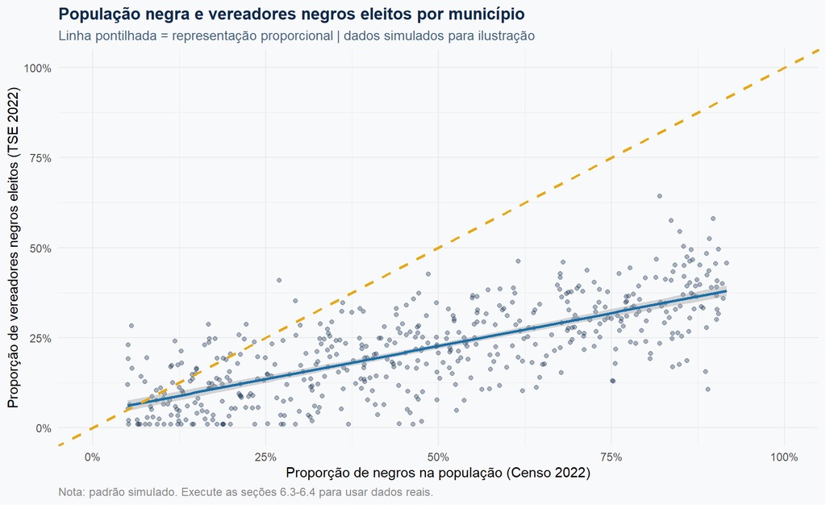

```r
ggplot(df_cruzado_sim, aes(x = prop_negros, y = prop_eleitos_negros)) +
  geom_point(alpha = 0.35, color = "#0f2a4a", size = 1.5) +
  geom_smooth(method = "lm", color = "#1a6fa8", se = TRUE) +
  geom_abline(slope = 1, intercept = 0, linetype = "dashed",
              color = "#e6a817", linewidth = 0.9) +
  scale_x_continuous(labels = percent_format(accuracy = 1), limits = c(0, 1)) +
  scale_y_continuous(labels = percent_format(accuracy = 1), limits = c(0, 1)) +
  labs(
    title    = "População negra e vereadores negros eleitos por município",
    subtitle = "Linha pontilhada = representação proporcional | dados simulados para ilustração",
    x        = "Proporção de negros na população (Censo 2022)",
    y        = "Proporção de vereadores negros eleitos (TSE 2022)",
    caption  = "Nota: padrão simulado. Execute as seções 6.3-6.4 para usar dados reais."
  ) +
  theme_minimal(base_family = "sans") +
  theme(
    plot.title       = element_text(color = "#0f2a4a", face = "bold", size = 13),
    plot.subtitle    = element_text(color = "#4a6580", size = 10.5),
    plot.caption     = element_text(color = "#888888", size = 9, hjust = 0),
    plot.background  = element_rect(fill = "#f8f9fb", color = NA),
    panel.background = element_rect(fill = "#f8f9fb", color = NA)
  )
```

```r
cor_val <- cor(df_cruzado_sim$prop_negros, df_cruzado_sim$prop_eleitos_negros)
print(paste("Correlação (prop. negros na população vs. eleitos):", round(cor_val, 3)))
```

```
#> [1] "Correlação (prop. negros na população vs. eleitos): 0.736"
```

A correlação indica a direção e a intensidade da associação entre as duas variáveis – mas é um passo descritivo. Para fazer afirmações sobre causalidade ou controlar por outras variáveis (porte do município, região, partido), seriam necessários modelos mais robustos. O que fazemos aqui é aprender a montar o dado: saber de onde vem cada variável e como cruzá-las já é o objetivo.

**Exercício 4** Use `query_candidatos` como base e escreva uma nova consulta SQL que retorne o total de votos recebidos por candidatos negros vs. não negros por estado. Você precisará juntar com `resultados_candidato` usando `id_candidato_bd`.

# 7 · Boas práticas

- A variável é autodeclaração ou heteroidentificação? Documente.
- A categoria “negros” está definida como pretos + pardos, com menção na primeira ocorrência?
- Os valores ausentes foram tratados de forma transparente?
- O tamanho amostral de cada grupo está reportado?
- O ano de referência e a edição da pesquisa estão citados?
- Se usou peso amostral (`V1028`), isso está na metodologia?

## 7.1 Referências

- IBGE (2022). [Desigualdades Sociais por Cor ou Raça no Brasil](https://biblioteca.ibge.gov.br/index.php/biblioteca-catalogo?view=detalhes&id=2101935).
- TSE (2025). Análise da distribuição de candidaturas por perfil racial, 2014-2024.
- Pacote [`censobr`](https://ipeagit.github.io/censobr/) – IPEA
- Pacote [`PNADcIBGE`](https://github.com/cran/PNADcIBGE)
- Pacote [`sidrar`](https://cran.r-project.org/web/packages/sidrar/vignettes/Introduction_to_sidrar.html)